# Open tools for more accessible and transparent biologically informed deep learning

David Selby

DFKI

AI4Sci 2026 · AI4LifeSciences · Mainz

Daria Pavliuk

DFKI

Gerrit Grossmann

DFKI

Sebastian Vollmer

DFKI

7 October 2026

## Why prior knowledge?

German Research Center for Artificial Intelligence · Data Science and its Applications

Cluster for Atherothrombosis and Individualised Medicine · Mainz

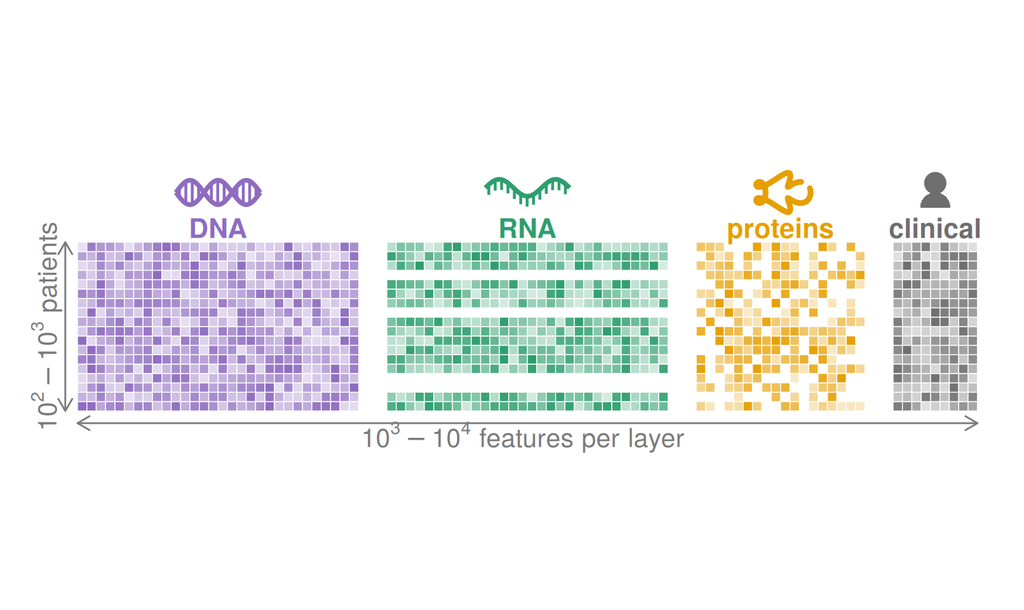

**small** · **noisy** · **high-dimensional** · **multimodal**

→ borrow strength from **prior knowledge**

## Wiring networks like biology

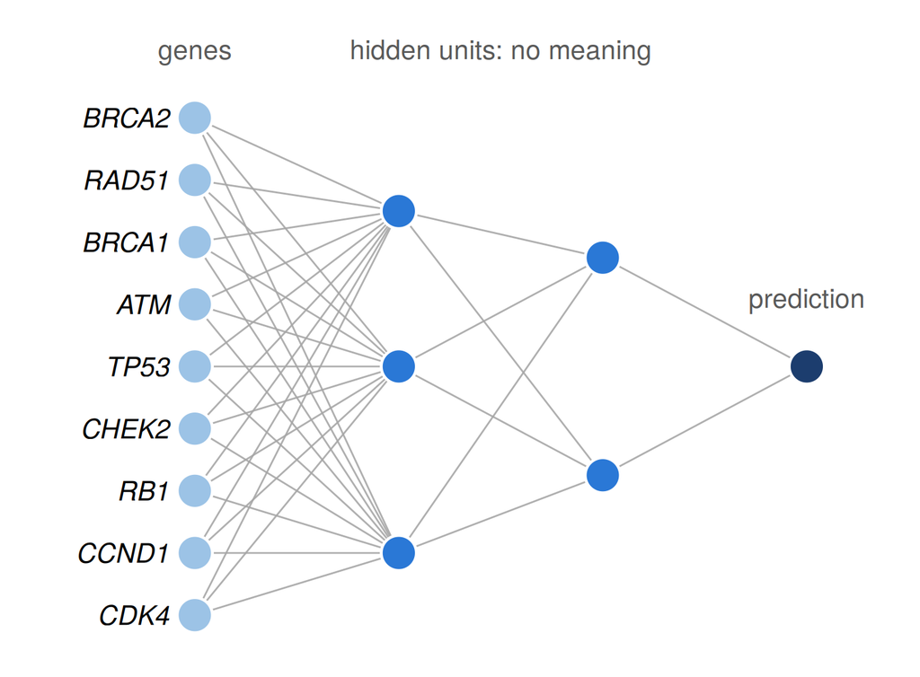

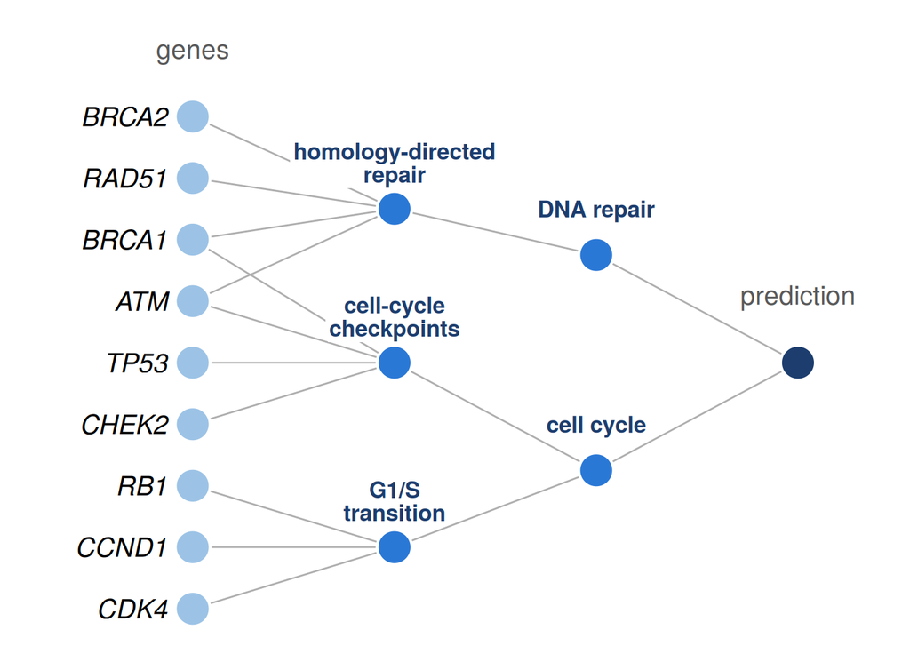

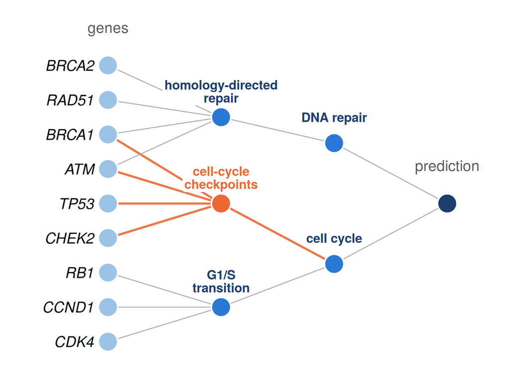

**inputs**, per patient and gene: mutated? copy number? activity?

**pathway**: genes whose products work together on one cellular job · curated (Reactome, GO) · nested

**BINN** = keep only the connections the database supports

→ **predict + explain**

P-NET (*Nature* 2021) · DCell (2018) · GenNet (2021) · BINN (2023)

## A crowded field

86

papers, 2018–2024

Selby et al., *Front. AI* 2025

- no shared **terminology**
- no shared **tools**
- no shared **benchmarks**

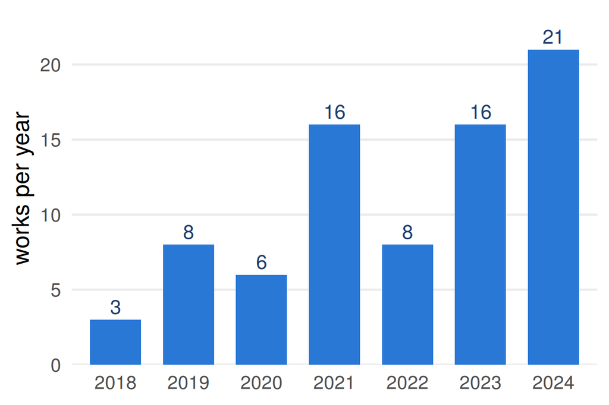

works listed in the review’s Table A.1 (n = 78), by year

## Under scrutiny

| question | study | finding |
| --- | --- | --- |
| **replicable?** | Pedersen et al. 2023 · *Cancer-Net* | P-NET reproduced; shuffled wiring **worse** |
| **stable?** | Esser-Skala & Fortelny 2023 | importance varies across retrainings, tracks network position |
| **does biology matter?** | Caranzano et al. 2026 · *“Sparsity is all you need”* | 20 models: random ≈ real |
| **what can it learn?** | Miller et al. 2026 · simulation | limited by *n*, signal, sparsity |
| **how many answers?** | Gankin et al. 2026 · 101 replicates | explanations correlate only ≈ 0.5 between reruns |

## Same model, opposite answers

**P-NET, shuffled wiring**

AUPR ≈ 0.89 → ≈ 0.83

*biology matters*

Pedersen et al. 2023

**P-NET, random wiring**

AUC 0.899 → 0.896

*sparsity is all you need*

Caranzano et al. 2026

Right **question**? Right **tool**?

## A BINN is message passing on a graph

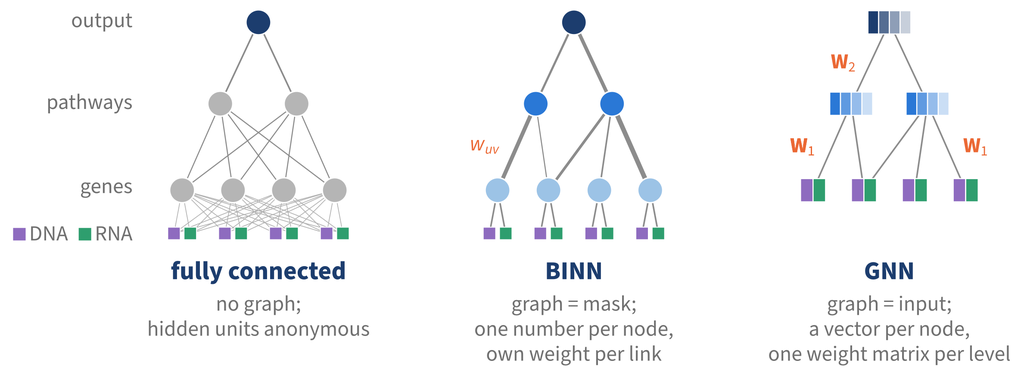

$\big[(\mathbf{W}\odot\mathbf{M})\,\mathbf{h}\big]_v \;=\; \textstyle\sum_{u\to v} w_{uv}\, h_u$ · masked layer = one round of message passing

hidden nodes have no data → **defined by position alone**

60% of P-NET’s genes: same pathways as another gene

## What is the null hypothesis?

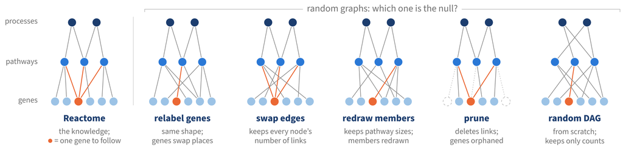

H₀: *“the knowledge is irrelevant”* · but **which** random graph?

**straw-man null**: reject it, claim the favoured alternative

Gelman 2016, *J. Stat. Res.*

## Can’t use it ≠ useless

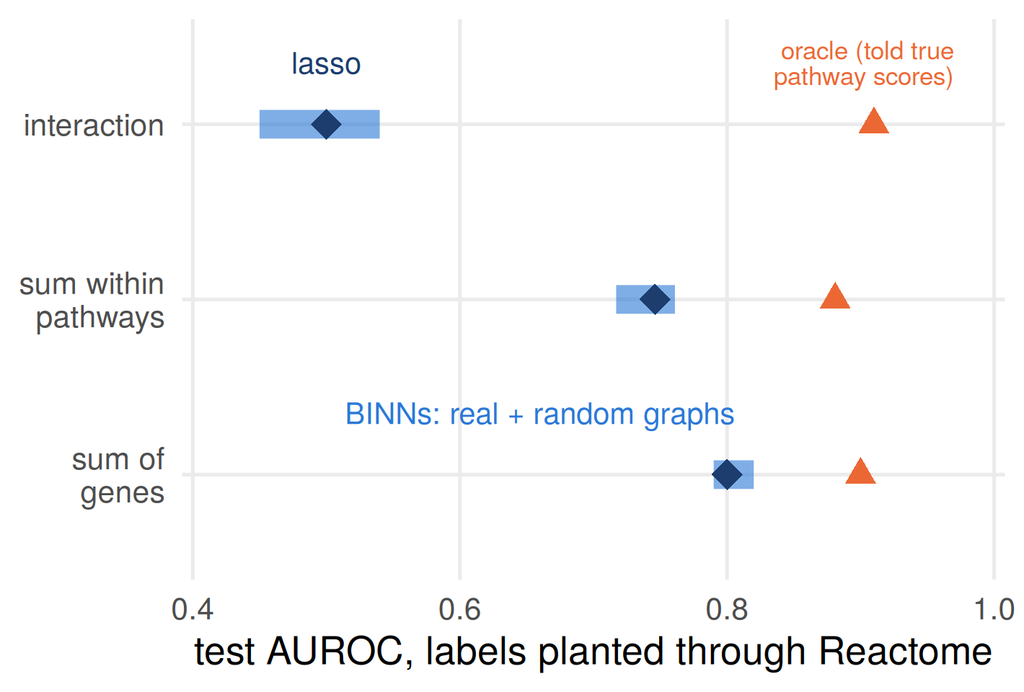

TCGA-PRAD RNA; Maani, Selby et al., in prep.

- labels built **through** real pathways
- real ≈ random ≈ lasso ≪ oracle
- no power → **no conclusion**

**ask instead**

- equivalence, not “*n.s.*”
- nested models: knowledge as a **penalty**
- positive controls

McShane, Gelman et al. 2019, *Am. Stat.*

## Every check is a new codebase

**graph baked into code**

- new null → new model
- new database → new model
- new data type → new paper

**ecosystem gap**

- BINNs: Python, one repo each
- R / Bioconductor: TCGA, `MultiAssayExperiment`, `limma`, `survival` … no BINNs

graph as **input** · checks as **one line**

## binnr

```r
library(binnr)
brca <- tcga_cohort("BRCA")                     # curatedTCGAData, cached
g    <- reactome_graph()                        # igraph DAG; any gene sets work

fit  <- bn_fit(Surv(os_time, os_event) ~ age + stage, data = brca$clinical,
               omics = brca$omics, graph = g, arch = bn_arch("binn"))

update(fit, graph = bn_rewire(g, "degree"))     # null graphs: one argument
update(fit, arch  = bn_arch("gnn", hidden_dim = 4))
node_activations(fit, new_omics)                # patients × nodes
```

`torch` · `igraph` · `MultiAssayExperiment` · formulas · tidy output · classification / regression / Cox

## What it shows

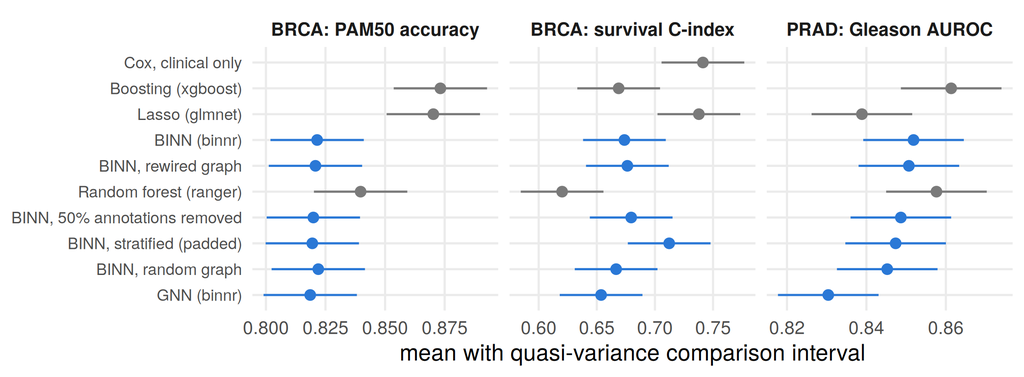

real vs random graphs: **no detectable difference** · lasso matches or beats BINNs · age + stage hard to beat on survival

TCGA BRCA (n = 960) & PRAD (n = 491); 5×5-fold CV, tuned within folds. Also reproduces P-NET’s split and Hartman et al.’s proteomics.

## Next — and who wants in?

**next**

- knowledge as **prior**, not mask
- hierarchy nulls · random DAGs
- missing modalities · covariates
- cardiovascular cohorts
- CRAN · Bioconductor

let’s talk: **data · nulls · use cases**

[figure not shown]

github.com/datasciapps/binnr

david.selby@dfki.de